# Data 622: Homework1

Santosh Manjrekar

2/19/2021

## 1. Logistic Regression with a binary outcome.

- 1. The penguin dataset has ‘species’ column. Please check how many categories you have in the species column. Conduct whatever data manipulation you need to do to be able to build a logistic regression with binary outcome. Please explain your reasoning behind your decision as you manipulate the outcome/dependent variable (species).
- 2. Please make sure you are evaluating the independent variables appropriately in deciding which ones should be in the model.
- 3. Provide variable interpretations in your model.

# Data Exploration

The penguins dataset has 344 observations and has one response or dependent variable (species) and 7 independent variables (island,bill_length_mm,bill_depth_mm,flipper_length_mm,body_mass_g,sex,year).

# Missing values

We will remove the records which has some of the column values as N/A

```r
#Remove NAs
penguins_data <- penguins_data %>% na.omit()
```

# Creating Binary variable isAdelie

```r
#Categories in species column
penguins_data %>%
  group_by(species) %>%
  count() #there are THREE categories
```

```
## # A tibble: 3 x 2
## # Groups:   species [3]
##   species       n
##   <fct>     <int>
## 1 Adelie      146
## 2 Chinstrap    68
## 3 Gentoo      119
```

After exploting data we see that there are 3 categories in species column (Adelie,Chinstrap and Gentoo). **From data it looks like “Adelie” is most popular category. In order to convert our outcome to binary outcome we can introduce two categories for species column “Adelie” or 1 and “Other” or 0.We will add isAdelie column for that.**

```r
# create isAdelie classification response variable
penguins_data <- penguins_data %>%
  mutate(isAdelie = ifelse(species == 'Adelie','Adelie','Other'))

penguins_data$isAdelie <- factor(penguins_data$isAdelie, levels = c("Other", "Adelie"))
```

# Evaluating Independent Variables

**Lets look at the correlation between the numeric variables. Looks like variables body_mass_g and flipper_length are positively correlated so we can consider one variable out of them in our model.**

```r
penguins_data %>% select_if(is.numeric) %>% cor()
```

```
##                   bill_length_mm bill_depth_mm flipper_length_mm body_mass_g
## bill_length_mm         1.0000000    -0.2286256         0.6530956  0.58945111
## bill_depth_mm         -0.2286256     1.0000000        -0.5777917 -0.47201566
## flipper_length_mm      0.6530956    -0.5777917         1.0000000  0.87297890
## body_mass_g            0.5894511    -0.4720157         0.8729789  1.00000000
## year                   0.0326569    -0.0481816         0.1510679  0.02186213
##                          year
## bill_length_mm     0.03265690
## bill_depth_mm     -0.04818160
## flipper_length_mm  0.15106792
## body_mass_g        0.02186213
## year               1.00000000
```

For continuous independent variables, we can get more clarity on the distribution by analyzing it w.r.t. dependent variable.

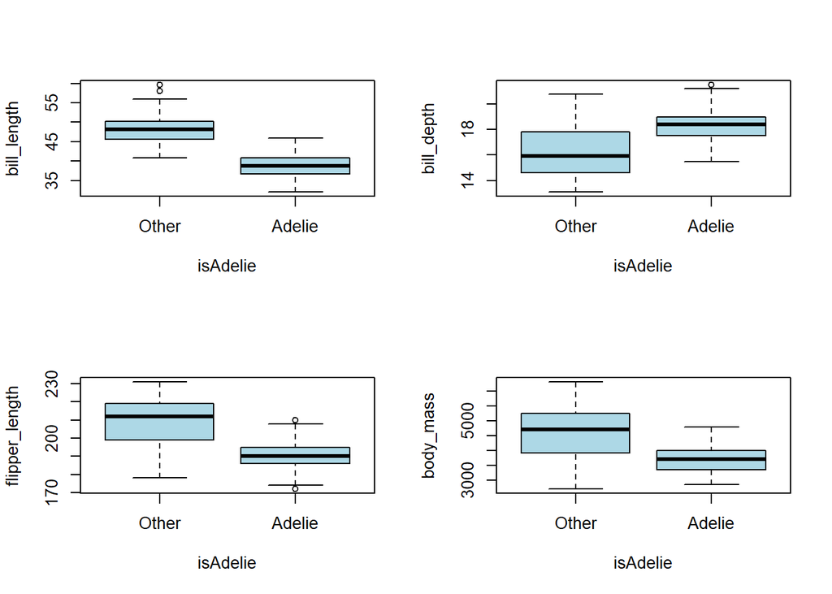

```r
par(mfrow = c(2,2))

boxplot(bill_length_mm~isAdelie, ylab="bill_length", xlab= "isAdelie", col="light blue",data = penguins_data)
boxplot(bill_depth_mm~isAdelie, ylab="bill_depth", xlab= "isAdelie", col="light blue",data = penguins_data)
boxplot(flipper_length_mm~isAdelie, ylab="flipper_length", xlab= "isAdelie", col="light blue",data = penguins_data)
boxplot(body_mass_g~isAdelie, ylab="body_mass", xlab= "isAdelie", col="light blue",data = penguins_data)
```

# Some observations are as follows

- Adelie species are smaller in length than other species
- Adelie species has more depth than other species
- Adelie species have smaller flipper length and body mass
- We can see that flipper length and body_mass variables are correlated

For categorical independent variables, we can analyze the frequency of each category w.r.t. the dependent variable

```r
xtabs(~isAdelie + year, data = penguins_data)
```

```
##         year
## isAdelie 2007 2008 2009
##   Other    59   63   65
##   Adelie   44   50   52
```

```r
xtabs(~isAdelie + sex, data = penguins_data)
```

```
##         sex
## isAdelie female male
##   Other      92   95
##   Adelie     73   73
```

# Some observations are as follows

- Year variable doesn’t look like much impact in identifying Adelie species
- Sex variable doesn’t look like much impact in identifying Adelie species

We can remove these variables from our dataset

```r
penguins_data <- subset(penguins_data, select = -c(year))
penguins_data <- subset(penguins_data, select = -c(sex))
```

Train-Test Split Lets split the data. Have 70% data to train the model and keep remaining 30% for testing purpose.

```r
which_train <- sample(x = c(TRUE, FALSE), size = nrow(penguins_data), replace = TRUE, prob = c(0.7, 0.3))
train_data <- penguins_data[which_train, ]
test_data <- penguins_data[!which_train, ]
```

# Binary Logistic Regression

```r
logmodel <- glm(isAdelie ~ island + bill_depth_mm + flipper_length_mm,
                 family = 'binomial',
                 data = train_data)

summary(logmodel)
```

```
##
## Call:
## glm(formula = isAdelie ~ island + bill_depth_mm + flipper_length_mm,
##     family = "binomial", data = train_data)
##
## Deviance Residuals:
##      Min        1Q    Median        3Q       Max
## -2.59262  -0.20631  -0.06577   0.08972   2.63842
##
## Coefficients:
##                     Estimate Std. Error z value Pr(>|z|)
## (Intercept)         37.51719    8.79948   4.264 2.01e-05 ***
## islandDream         -3.80276    1.03652  -3.669 0.000244 ***
## islandTorgersen     16.96797 1505.96799   0.011 0.991010
## bill_depth_mm        0.75693    0.20186   3.750 0.000177 ***
## flipper_length_mm   -0.24812    0.04305  -5.763 8.25e-09 ***
## ---
## Signif. codes:  0 '***' 0.001 '**' 0.01 '*' 0.05 '.' 0.1 ' ' 1
##
## (Dispersion parameter for binomial family taken to be 1)
##
##     Null deviance: 341.80  on 248  degrees of freedom
## Residual deviance: 101.93  on 244  degrees of freedom
## AIC: 111.93
##
## Number of Fisher Scoring iterations: 18
```

# Coefficient Intrepretation

Larger the coefficient there will be more of an impact on the positive classification or it being Adelie species. So variables having positive coefficients are being more indicative of Adelie species and negative coefficients as being indicative of no Adelie species.

Some interesting observations

- island: If a penguin lives on Dream island it is less likely to be of the Adelie species. If it lives on Torgersen it is more likely to be of the Adelie species.
- bill_depth_mm: A positive value means that the larger the bill depth, the more likely the penguin is of the Adelie species.
- flipper_length_mm: A negative value means that the larger the flipper size, the less likely the penguin is of the Adelie species.

All of these coefficients align with our previous exploratory analysis!

## 2. Metrics

```r
log_preds <- predict(logmodel, test_data, type = 'response')
class_prediction <- factor(ifelse(log_preds > 0.50, "Adelie", "Other"),
                           levels = c("Other", "Adelie"))

log_auc <- auc(response = test_data$isAdelie, predictor = log_preds)
log_cm <- confusionMatrix(data = class_prediction, reference =test_data$isAdelie)
log_accuracy <- log_cm$overall['Accuracy']
log_tpr <- log_cm$byClass['Sensitivity']
log_fpr <- 1 - log_tpr
log_tnr <- log_cm$byClass['Specificity']
log_fnr <- 1 - log_tnr
```

## 3. Multinomial Logistic Regression

First, we will define “Adelie” as the reference level (or “baseline species”) for the dataset. This means that our trained model will result in coefficients of the features for the remaining two species in relation to Adelie. We will start with a baseline model that includes all features.

```r
require(nnet)
train_data$species <- relevel(train_data$species, ref = "Adelie")
test_data$species <- relevel(test_data$species, ref = "Adelie")

multinom_model <- multinom(species ~ ., data = train_data %>% select(-isAdelie))
summary(multinom_model)
```

```
## Call:
## multinom(formula = species ~ ., data = train_data %>% select(-isAdelie))
##
## Coefficients:
##           (Intercept) islandDream islandTorgersen bill_length_mm bill_depth_mm
## Chinstrap  -136.36389    32.93073       -14.42726       14.13510     -19.90270
## Gentoo      -10.21908   -46.22665       -39.47398        8.73007     -18.41169
##           flipper_length_mm body_mass_g
## Chinstrap        -0.2377843 -0.02749231
## Gentoo           -0.6030912  0.01881209
##
## Std. Errors:
##           (Intercept)  islandDream islandTorgersen bill_length_mm bill_depth_mm
## Chinstrap   0.6957534 1.403937e+00             NaN      101.64960     54.922341
## Gentoo      0.1268320 8.301517e-17    8.486003e-08        8.75875      4.370859
##           flipper_length_mm body_mass_g
## Chinstrap          18.21333   0.5917839
## Gentoo             30.70866   1.3707121
##
## Residual Deviance: 0.000474253
## AIC: 28.00047
```